# Capstone Project for DTSC 691

## Eastern University

### Food Desert analysis for the greater Pittsburgh area

The goal of this final project is to determine which factors and which classification model best predict food desert status for Allegheny County. The USDA defines a food desert as an area which is both low income and low access to healthy food options. The area of measurement for all of these datasets will be the census tract. For this research, I chose a food desert indicator where the census tract is low income and 1 mile away from healthy food in urban areas and 10 miles away in rural areas. All of Allegheny county is considered an urban area due to its cities' promixity to Pittsburgh.

# Data Description

### A 20 feature data frame will be created with the significant values from each of these datasets

#### All of the following datasets were obtained from the [Western Pennsylvania Regional Data Center](https://data.wprdc.org/organization/allegheny-county), all data representing 2016 unless otherwise noted:

- [Obesity Rates 2006-2010](https://data.wprdc.org/dataset/allegheny-county-obesity-rates) (.csv)
- [Diabetes and Hypertension comorbidity](https://data.wprdc.org/dataset/diabetes-hypertension-comorbidity) (.csv)
  - the diabetes/hypertension dataset was in the form of count of total insured VS count of individuals diagnosed diabetes and hypertension
- [2016 Allegheny County Census Tracts](https://data.wprdc.org/dataset/allegheny-county-census-tracts-20161) (.geojson)
  - imported this data because it contains the abbreviated census tract which matches the obesity/diabetes/hypertension (health) dataframe
  - it also contains the geometry information which allows me merge the health dataframe with it and plot a choropleth map corresponding to the rate of obesity or diabetes and hypertension
- [Fast Food Restaurant Locations in Allegheny County](https://data.wprdc.org/dataset/allegheny-county-fast-food) (.geojson)
  - contains the latitude and longitude point of each "fast food" restaurant in Allegheny county
  - fast food, here, is considered a "chain restaurant which does not serve alcohol"
- [Supermarkets and Convenience Stores in Allegheny County](https://data.wprdc.org/dataset/allegheny-county-supermarkets-convenience-stores) (.geojson)
  - contains latitude and longitude points for each supermarket and convenience store in Allegheny county
  - this dataset had some erroneous latitude/longitude values which were discovered when trying to plot the data over a map Allegheny county
- [Allegheny County Walk Scores](https://data.wprdc.org/dataset/allegheny-county-walk-scores) (.csv)
  - as Pittsburgh/Allegheny county is not a very flat area, I wanted to see if there was any correlation between having a low walk score (not a viable option to walk 1 mile to the grocery store) and food desert status

#### From the USDA, the [Food Access Research Atlas](https://www.ers.usda.gov/data-products/food-access-research-atlas/) was used to incorporate multiple variables

- the most important variable it contained was a label encoded food desert status column where 1 indicated a food desert census tract and 0 indicated a census tract which was not a food desert, also known as a food oasis
- other variables it included were poverty rate, number of individuals in a certain race, median family income, individuals recieving SNAP benefits, and number of individuals over 65

#### From the United States Census, I exported data on [educational attainment](https://data.census.gov/cedsci/table?t=Educational%20Attainment&g=0500000US42003%241400000&tid=ACSST5Y2019.S1501) for each census tract in Allegheny County

- this dataset had a huge number of columns which I narrowed down to the population of the census tract and the number of individuals who did not graduate high school, graduated high school, have an associates degree or has taken some college classes, and those who have a bachelor's degree or higher.

## First, health data will be imported

- Obesity rates
- Diabetes with Hypertension population counts

```python
import numpy as np
import pandas as pd
import geopandas as gpd
```

```python
# importing obesity rates
obese = pd.read_csv("datasets/obesity-ac-2006-2010censustracts.csv")

# renaming the census tract column to match the diabetes/hypertension dataframe
obese = obese.rename({'2000 Tract':'census_tract', '2006-2010 estimate of obesity':'obesity_rate'}, axis=1)

obese.head()
```

|  | stname | tractfips | census_tract | 2010 Tract | MUNICIPALITY | Municipality | City Neighborhood | obesity_rate |
| --- | --- | --- | --- | --- | --- | --- | --- | --- |
| 0 | Pennsylvania | 42003010300 | 10300 | NaN | PITTSBURGH | Pittsburgh | Bluff | 0.246936 |
| 1 | Pennsylvania | 42003020100 | 20100 | NaN | PITTSBURGH | Pittsburgh | Central Business District | 0.668012 |
| 2 | Pennsylvania | 42003020300 | 20300 | NaN | PITTSBURGH | Pittsburgh | Strip District | 0.369996 |
| 3 | Pennsylvania | 42003030500 | 30500 | NaN | PITTSBURGH | Pittsburgh | Crawford Roberts | 0.488691 |
| 4 | Pennsylvania | 42003040200 | 40200 | NaN | PITTSBURGH | Pittsburgh | West oakland | 0.366391 |

```python
# importing diabetes and hypertension data
diabetes = pd.read_csv("datasets/diabetes_hypertension_allegheny.csv")

# again renaming to match with obesity dataframe
diabetes = diabetes.rename(columns={'CT':'census_tract'})

diabetes.head()
# column names are clearly abbreviations which cannot be understood without a dictionary
```

|  | census_tract | BTPAD | BTPAN | BTWAD | BTWAN | BTMAD | BTMAN |
| --- | --- | --- | --- | --- | --- | --- | --- |
| 0 | 10300 | 422 | 18 | 197 | 8 | 225 | 10 |
| 1 | 20100 | 2610 | 70 | 1242 | 22 | 1368 | 48 |
| 2 | 20300 | 354 | 11 | 175 | 3 | 179 | 8 |
| 3 | 30500 | 859 | 121 | 553 | 93 | 306 | 28 |
| 4 | 40200 | 388 | 37 | 233 | 25 | 155 | 12 |

```python
## dictionary for this dataset will translate the abbreviations used above
diab_dict = pd.read_csv('datasets/diabetes-hypertension-data-dictionary.csv')

diab_dict
```

|  | Code | Description |
| --- | --- | --- |
| 0 | CT | Census Tract |
| 1 | BTPAD | Total number of members, who are Allegheny Cou... |
| 2 | BTPAN | Total number of members who met the denominato... |
| 3 | BTWAD | Total number of women members, who are Alleghe... |
| 4 | BTWAN | Total number of women members who met the deno... |
| 5 | BTMAD | Total number of male members, who are Alleghen... |
| 6 | BTMAN | Total number of male members who met the denom... |

```python
# now I can merge the obesity and diabetes/hypertension dataframes on census_tract
poorhealth = obese.merge(diabetes, how = 'inner', on = ['census_tract'])

# and add diabetes/hypertension rates for all people in Allegheny county
## since I'm looking at the county as a whole, I don't think breaking up diabetes/hypertension rates into men and
## women is necessary
poorhealth['diabhyper_rate'] = poorhealth['BTPAN']/poorhealth['BTPAD']

poorhealth.head()
## this still has the abbreviated column names from diabetes df and some duplicate columns which need to be dropped
```

|  | stname | tractfips | census_tract | 2010 Tract | MUNICIPALITY | Municipality | City Neighborhood | obesity_rate | BTPAD | BTPAN | BTWAD | BTWAN | BTMAD | BTMAN | diabhyper_rate |
| --- | --- | --- | --- | --- | --- | --- | --- | --- | --- | --- | --- | --- | --- | --- | --- |
| 0 | Pennsylvania | 42003010300 | 10300 | NaN | PITTSBURGH | Pittsburgh | Bluff | 0.246936 | 422 | 18 | 197 | 8 | 225 | 10 | 0.042654 |
| 1 | Pennsylvania | 42003020100 | 20100 | NaN | PITTSBURGH | Pittsburgh | Central Business District | 0.668012 | 2610 | 70 | 1242 | 22 | 1368 | 48 | 0.026820 |
| 2 | Pennsylvania | 42003020300 | 20300 | NaN | PITTSBURGH | Pittsburgh | Strip District | 0.369996 | 354 | 11 | 175 | 3 | 179 | 8 | 0.031073 |
| 3 | Pennsylvania | 42003030500 | 30500 | NaN | PITTSBURGH | Pittsburgh | Crawford Roberts | 0.488691 | 859 | 121 | 553 | 93 | 306 | 28 | 0.140861 |
| 4 | Pennsylvania | 42003040200 | 40200 | NaN | PITTSBURGH | Pittsburgh | West oakland | 0.366391 | 388 | 37 | 233 | 25 | 155 | 12 | 0.095361 |

```python
## getting rid of duplicates and end up with a final health measure dataframe, with FULL and shortened census tracts
health = poorhealth[['tractfips', 'census_tract','obesity_rate',
                    'diabhyper_rate']]

health.head()
```

|  | tractfips | census_tract | obesity_rate | diabhyper_rate |
| --- | --- | --- | --- | --- |
| 0 | 42003010300 | 10300 | 0.246936 | 0.042654 |
| 1 | 42003020100 | 20100 | 0.668012 | 0.026820 |
| 2 | 42003020300 | 20300 | 0.369996 | 0.031073 |
| 3 | 42003030500 | 30500 | 0.488691 | 0.140861 |
| 4 | 42003040200 | 40200 | 0.366391 | 0.095361 |

## Next the geographical data will imported and mapped for Allegheny county

```python
# import census tract map using GeoPandas
alleg_geo = gpd.read_file('Allegheny_County_Census_Tracts_2016.geojson')
```

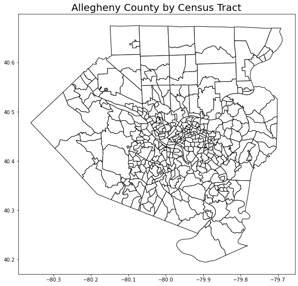

```python
# necessary packages for plotting geographic data
import plotly.figure_factory as ff
import geoplot as gplt
import matplotlib.pyplot as plt

fig, ax = plt.subplots(1, 1, figsize=(10, 10))

alleg_geo.plot(color='white', ax=ax, edgecolor='black')

ax.set_title('Allegheny County by Census Tract', fontsize=20)

plt.show()
```

```python
### Health data will be combined with the Allegheny county geodata to be able to make a choropleth map
# in this case, the tractfips numbers from the health data match the GEOID from the Allegheny county geodata
health = health.rename(columns={'tractfips':'GEOID'}).round({'obesity_rate':2,
                                                             "diabhyper_rate":3})

alleg_geo = alleg_geo.astype({'GEOID':int})

fullHealth = alleg_geo.merge(health, on='GEOID')

fullHealth
```

|  | FID | STATEFP | COUNTYFP | TRACTCE | AFFGEOID | GEOID | NAME | LSAD | ALAND | AWATER | SHAPE_Length | SHAPE_Area | geometry | census_tract | obesity_rate | diabhyper_rate |
| --- | --- | --- | --- | --- | --- | --- | --- | --- | --- | --- | --- | --- | --- | --- | --- | --- |
| 0 | 1 | 42 | 003 | 050900 | 1400000US42003050900 | 42003050900 | 509 | CT | 452643.0 | 4114.0 | 0.045048 | 0.000046 | MULTIPOLYGON (((-79.98390 40.44853, -79.98095 ... | 50900 | 0.64 | 0.085 |
| 1 | 2 | 42 | 003 | 070300 | 1400000US42003070300 | 42003070300 | 703 | CT | 428546.0 | 0.0 | 0.028484 | 0.000046 | MULTIPOLYGON (((-79.94095 40.45132, -79.93681 ... | 70300 | 0.13 | 0.029 |
| 2 | 3 | 42 | 003 | 120700 | 1400000US42003120700 | 42003120700 | 1207 | CT | 514927.0 | 0.0 | 0.031372 | 0.000055 | MULTIPOLYGON (((-79.90955 40.45670, -79.90804 ... | 120700 | 0.57 | 0.113 |
| 3 | 4 | 42 | 003 | 140400 | 1400000US42003140400 | 42003140400 | 1404 | CT | 834995.0 | 0.0 | 0.038374 | 0.000089 | MULTIPOLYGON (((-79.92158 40.44768, -79.92023 ... | 140400 | 0.15 | 0.025 |
| 4 | 5 | 42 | 003 | 180700 | 1400000US42003180700 | 42003180700 | 1807 | CT | 393380.0 | 0.0 | 0.026142 | 0.000042 | MULTIPOLYGON (((-80.00561 40.42702, -80.00384 ... | 180700 | 0.28 | 0.090 |
| ... | ... | ... | ... | ... | ... | ... | ... | ... | ... | ... | ... | ... | ... | ... | ... | ... |
| 353 | 398 | 42 | 003 | 141000 | 1400000US42003141000 | 42003141000 | 1410 | CT | 507878.0 | 0.0 | 0.046226 | 0.000055 | MULTIPOLYGON (((-79.90137 40.42724, -79.89868 ... | 141000 | 0.16 | 0.030 |
| 354 | 399 | 42 | 003 | 202300 | 1400000US42003202300 | 42003202300 | 2023 | CT | 2532255.0 | 0.0 | 0.075588 | 0.000270 | MULTIPOLYGON (((-80.04760 40.40779, -80.04373 ... | 202300 | 0.24 | 0.079 |
| 355 | 400 | 42 | 003 | 320600 | 1400000US42003320600 | 42003320600 | 3206 | CT | 1479651.0 | 0.0 | 0.053969 | 0.000159 | MULTIPOLYGON (((-80.01502 40.39296, -80.01398 ... | 320600 | 0.28 | 0.058 |
| 356 | 401 | 42 | 003 | 408001 | 1400000US42003408001 | 42003408001 | 4080.01 | CT | 26224976.0 | 0.0 | 0.220845 | 0.002790 | MULTIPOLYGON (((-79.99418 40.67364, -79.98785 ... | 408001 | 0.24 | 0.063 |
| 357 | 402 | 42 | 003 | 414101 | 1400000US42003414101 | 42003414101 | 4141.01 | CT | 9630782.0 | 0.0 | 0.140146 | 0.001024 | MULTIPOLYGON (((-79.95378 40.57802, -79.95179 ... | 414101 | 0.23 | 0.045 |

358 rows × 16 columns

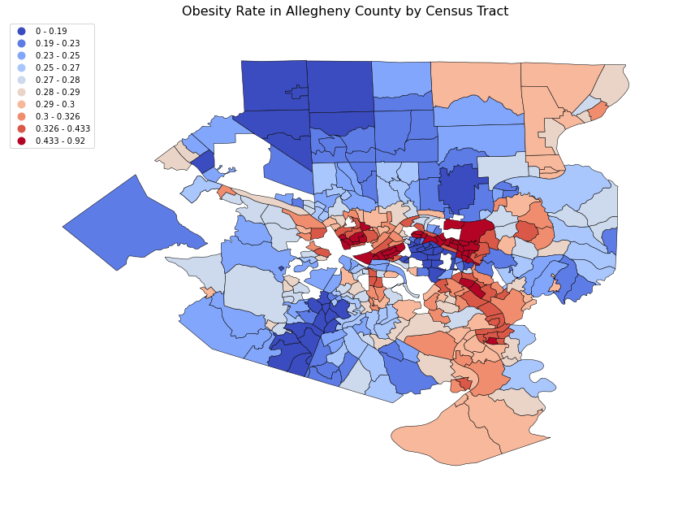

```python
fig, ax = plt.subplots(1, 1, figsize=(15, 15))

# import custom color scheme creator
import mapclassify as mc
scheme = mc.Quantiles(fullHealth['obesity_rate'], k=10)
## k value of 10 was chosen due to the color scheme changing to red at around 30% obesity which, at the time of
## collection of this data, was the US average obesity rate
### dark red indicating a very high percentage of the population being considered obese

gplt.choropleth(fullHealth, hue="obesity_rate", linewidth=.5, scheme=scheme,
                cmap='coolwarm', legend=True, ax=ax)

ax.set_title('Obesity Rate in Allegheny County by Census Tract', fontsize=16)

plt.show()
```

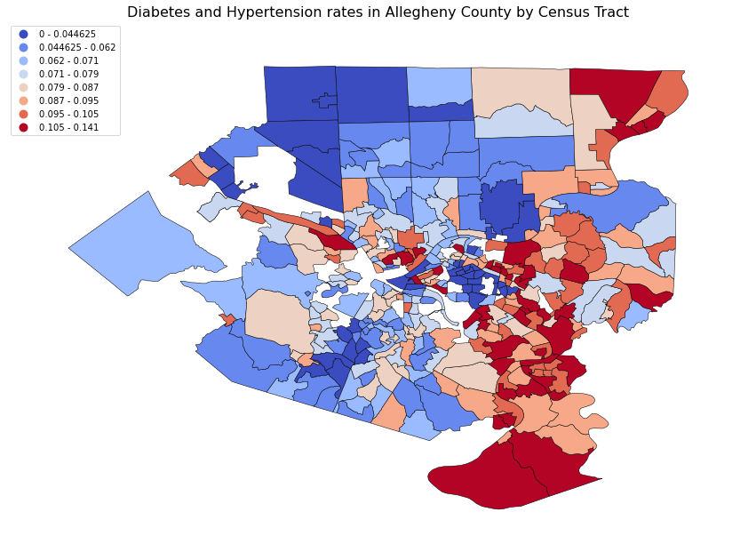

```python
fig, ax = plt.subplots(1, 1, figsize=(15, 15))

scheme = mc.Quantiles(fullHealth["diabhyper_rate"], k=8)
## In this case, a k value of 8 spread the data out better over the color scheme

gplt.choropleth(fullHealth, hue="diabhyper_rate", linewidth=.5, scheme=scheme,
                cmap='coolwarm', legend=True, ax=ax)

ax.set_title('Diabetes and Hypertension rates in Allegheny County by Census Tract', fontsize=16)

plt.show()
```

## Next step is to import data on fast food restaurants across Allegheny county

```python
fastfood = pd.read_csv('fastfoodalleghenycountyupdatexy2.csv')
```

```python
from shapely.geometry import Point, LineString, shape

# combine latitude and longitude columns to make a geodataframe where I can plot the geometry coordinates
newgeo = [Point(xy) for xy in zip(fastfood.Lon, fastfood.Lat)]

# crs is set to let GeoPandas know that the geometry values are latitude and longitude values
fastfood_geo = gpd.GeoDataFrame(fastfood, geometry=newgeo).set_crs(4326)

fastfood_geo.head()
```

|  | Name | Legal Name | Start Date | Street Number | Street Name | ZIP Code | Lat | Lon | Category | geometry |
| --- | --- | --- | --- | --- | --- | --- | --- | --- | --- | --- |
| 0 | Adrian's Pizza | NaN | 11/7/2014 | 605 | Thompson Run Rd | 15237 | 40.539465 | -79.990764 | Take Out | POINT (-79.99076 40.53946) |
| 1 | Adrian's Pizza Express | Rock Enterprises Inc | 4/22/2004 | 7824 | Perry Hwy | 15237 | 40.551219 | -80.037362 | Take Out | POINT (-80.03736 40.55122) |
| 2 | Allegheny Sandwich Shop | NaN | 2/24/1997 | 414 | Grant St | 15219 | 40.438110 | -79.996860 | NO Dollar Menu | POINT (-79.99686 40.43811) |
| 3 | Allegheny Sandwich Shoppe #3 | Allegheny Sandwich Shoppe Inc | 11/9/2001 | 440 | Ross St | 15219 | 40.438514 | -79.995330 | NO Dollar Menu | POINT (-79.99533 40.43851) |
| 4 | Amili's Pizzeria | NaN | 2/26/1999 | 1021 | Brownsville Rd | 15210 | 40.406082 | -79.991863 | Take Out | POINT (-79.99186 40.40608) |

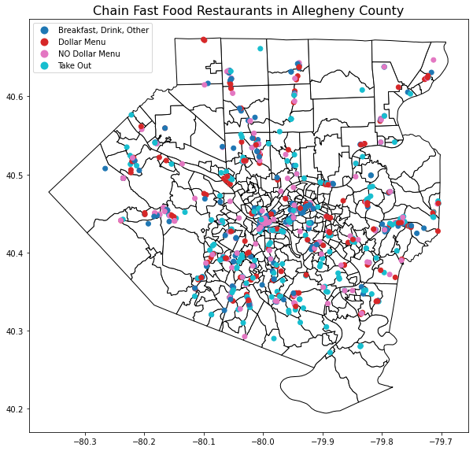

```python
# visualize the amount of fast food locations
fig, ax = plt.subplots(1, 1, figsize=(10, 10))

alleg_geo.plot(color='white', ax=ax, edgecolor='black')
fastfood_geo.plot(column='Category', ax=ax, legend=True)

ax.set_title('Chain Fast Food Restaurants in Allegheny County', fontsize=16)

plt.show()
```

## Now grocery store data will be imported

```python
grocery = pd.read_csv('supermarketsalleg.csv')

# noticed some odd rows where all were NaN so I dropped them
grocery = grocery.dropna(thresh=2)

## noticed more odd values in the longitude column which did not make sense for the area I am studying
## made parameters that require all values to be within Allegheny county latitude/longitude
grocery = grocery[grocery['Lon'] < -77.5]
grocery = grocery[grocery['Lon'] > -80.4]
grocery = grocery[grocery['Lat'] > 40.2]
```

### From this screenshot of the plot you can see the issues I was having with latitude and longitude values:

[figure not shown]

```python
# again combining latitude and longitude into a point geometry column to be able to use in geopandas
supergeo = [Point(xy) for xy in zip(grocery.Lon, grocery.Lat)]

grocery_geo = gpd.GeoDataFrame(grocery, crs=4326, geometry=supergeo)

# making it easier to combine supermarket and fastfood dataframes.... they now have the same column names
grocery_geo = grocery_geo.drop(columns=['Client ID', 'Accuracy'])
```

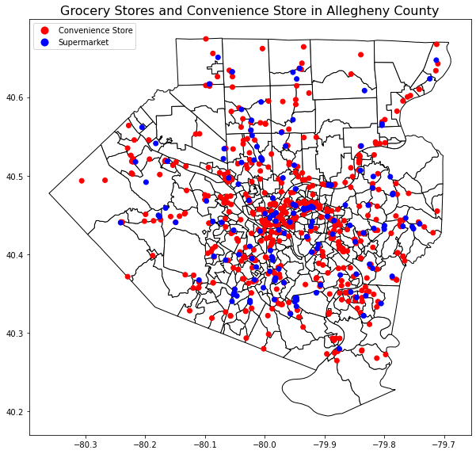

```python
# visualize the amount of grocery stores and convenience stores
fig, ax = plt.subplots(1, 1, figsize=(10, 10))

# make my own listed color map because the given matplotlib cmaps do not look very good with 2 values
from matplotlib.colors import ListedColormap
storemap = ListedColormap(['red', "blue"])

alleg_geo.plot(color='white', ax=ax, edgecolor='black')
grocery_geo.plot(column='Category', ax=ax, cmap=storemap, legend=True)

ax.set_title('Grocery Stores and Convenience Store in Allegheny County', fontsize=16)

plt.show()
```

```python
## both fast food and grocery stores and convenience stores are now together in one geoDataFrame
foodopts = grocery_geo.append(fastfood_geo).reset_index()
```

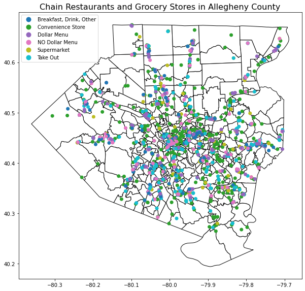

```python
# visualize the amount of all food options
fig, ax = plt.subplots(1, 1, figsize=(10, 10))

alleg_geo.plot(color='white', ax=ax, edgecolor='black')
foodopts.plot(column='Category', ax=ax, legend=True)

ax.set_title('Chain Restaurants and Grocery Stores in Allegheny County', fontsize=16)

plt.show()
```

## The large dataset respresenting the Food Access Research Atlas for the entire United States will be imported and reduced to be only Allegheny county

```python
# import the excel files
FARAsheets = pd.ExcelFile('FoodAccessResearchAtlasData2019.xlsx')

# specify which sheet to get the data from
FARA = pd.read_excel(FARAsheets, 'Food Access Research Atlas')
```

```python
# here we are only concerned with Allegheny county so it will be isolated
allegFARA = FARA[FARA['County'] == 'Allegheny County']

allegFARA = allegFARA.reset_index()

## would like to see all of the columns available
pd.set_option('display.max_columns', None)
allegFARA.head()
```

|  | index | CensusTract | State | County | Urban | Pop2010 | OHU2010 | GroupQuartersFlag | NUMGQTRS | PCTGQTRS | LILATracts_1And10 | LILATracts_halfAnd10 | LILATracts_1And20 | LILATracts_Vehicle | HUNVFlag | LowIncomeTracts | PovertyRate | MedianFamilyIncome | LA1and10 | LAhalfand10 | LA1and20 | LATracts_half | LATracts1 | LATracts10 | LATracts20 | LATractsVehicle_20 | LAPOP1_10 | LAPOP05_10 | LAPOP1_20 | … |
| --- | --- | --- | --- | --- | --- | --- | --- | --- | --- | --- | --- | --- | --- | --- | --- | --- | --- | --- | --- | --- | --- | --- | --- | --- | --- | --- | --- | --- | --- | --- |
| 0 | 54957 | 42003010300 | Pennsylvania | Allegheny County | 1 | 6600 | 282 | 1 | 6012.0 | 91.090909 | 0 | 1 | 0 | 0 | 0 | 1 | 46.124524 | 17161.0 | 0 | 1 | 0 | 1 | 0 | 0 | 0 | 0 | NaN | 5739.390942 | NaN | … |
| 1 | 54958 | 42003020100 | Pennsylvania | Allegheny County | 1 | 3629 | 1906 | 0 | 1091.0 | 30.063378 | 0 | 0 | 0 | 0 | 1 | 0 | 17.465070 | 137463.0 | 0 | 1 | 0 | 1 | 0 | 0 | 0 | 1 | 0.0 | 2361.322165 | 0.0 | … |
| 2 | 54959 | 42003020300 | Pennsylvania | Allegheny County | 1 | 616 | 403 | 0 | 0.0 | 0.000000 | 0 | 0 | 0 | 0 | 0 | 0 | 6.372549 | 124722.0 | 0 | 0 | 0 | 0 | 0 | 0 | 0 | 0 | NaN | NaN | NaN | … |
| 3 | 54960 | 42003030500 | Pennsylvania | Allegheny County | 1 | 2256 | 1154 | 0 | 116.0 | 5.141844 | 0 | 0 | 0 | 0 | 0 | 1 | 39.484215 | 26976.0 | 0 | 0 | 0 | 0 | 0 | 0 | 0 | 0 | NaN | 0.000000 | NaN | … |
| 4 | 54961 | 42003040200 | Pennsylvania | Allegheny County | 1 | 2604 | 594 | 0 | 1259.0 | 48.348694 | 0 | 1 | 0 | 1 | 1 | 1 | 47.884013 | 34813.0 | 0 | 1 | 0 | 1 | 0 | 0 | 0 | 1 | NaN | 2481.888637 | NaN | … |

```python
# read in the sheet which contains the data dictionary for the Food Access Research Atlas
FARAdictionary = pd.read_excel(FARAsheets, 'Variable Lookup')

## want to see all of the values to decide which columns to take for the final df
pd.set_option('display.max_rows', None)
FARAdictionary
```

|  | Field | LongName | Description |
| --- | --- | --- | --- |
| 0 | CensusTract | Census tract | Census tract number |
| 1 | State | State | State name |
| 2 | County | County | County name |
| 3 | Urban | Urban tract | Flag for urban tract |
| 4 | POP2010 | Population, tract total | Population count from 2010 census |
| 5 | OHU2010 | Housing units, total | Occupied housing unit count from 2010 census |
| 6 | GroupQuartersFlag | Group quarters, tract with high share | Flag for tract where >=67% |
| 7 | NUMGQTRS | Group quarters, tract population residing in, ... | Count of tract population residing in group qu... |
| 8 | PCTGQTRS | Group quarters, tract population residing in, ... | Percent of tract population residing in group ... |
| 9 | LILATracts_1And10 | Low income and low access tract measured at 1 ... | Flag for low-income and low access when consid... |
| 10 | LILATracts_halfAnd10 | Low income and low access tract measured at 1/... | Flag for low-income and low access when consid... |
| 11 | LILATracts_1And20 | Low income and low access tract measured at 1 ... | Flag for low-income and low access when consid... |
| 12 | LILATracts_Vehicle | Low income and low access tract using vehicle ... | Flag for low-income and low access when consid... |
| 13 | HUNVFlag | Vehicle access, tract with low vehicle access | Flag for tract where >= 100 of households do n... |
| 14 | LowIncomeTracts | Low income tract | Flag for low income tract |
| 15 | PovertyRate | Tract poverty rate | Share of the tract population living with inco... |
| 16 | MedianFamilyIncome | Tract median family income | Tract median family income |
| 17 | LA1and10 | Low access tract at 1 mile for urban areas and... | Flag for low access tract at 1 mile for urban ... |
| 18 | LAhalfand10 | Low access tract at 1/2 mile for urban areas a... | Flag for low access tract at 1/2 mile for urba... |
| 19 | LA1and20 | Low access tract at 1 mile for urban areas and... | Flag for low access tract at 1 mile for urban ... |
| 20 | LATracts_half | Low access tract at 1/2 mile | Flag for low access tract when considering 1/2... |
| 21 | LATracts1 | Low access tract at 1 mile | Flag for low access tract when considering 1 m... |
| 22 | LATracts10 | Low access tract at 10 miles | Flag for low access tract when considering 10 ... |
| 23 | LATracts20 | Low access tract at 20 miles | Flag for low access tract when considering 20 ... |
| 24 | LATractsVehicle_20 | Low access tract using vehicle access and at 2... | Flag for tract where >= 100 of households do n... |
| 25 | LAPOP1_10 | Low access, population at 1 mile for urban are... | Population count beyond 1 mile for urban areas... |
| 26 | LAPOP05_10 | Low access, population at 1/2 mile for urban a... | Population count beyond 1/2 mile for urban are... |
| 27 | LAPOP1_20 | Low access, population at 1 mile for urban are... | Population count beyond 1 mile for urban areas... |
| 28 | LALOWI1_10 | Low access, low-income population at 1 mile fo... | Low income population count beyond 1 mile for ... |
| 29 | LALOWI05_10 | Low access, low-income population at 1/2 mile ... | Low income population count beyond 1/2 mile fo... |

[output cut: 117 more lines]

## With this dictionary I can see I only need the following columns:

```
0-5 are self explanatory
9. LILATract_1And!0 = *food desert* low income low access 1 mile for urban area and 10 miles for rural
15. PovertyRate = poverty rate for that tract
16. MedianFamilyIncome = tract median family income
137. TractSeniors = number of individuals over 65 in a tract
138. TractWhite = number of individuals in a tract who are white
139. TractBlack = number of individuals in a tract who are black
140. TractAsian = number of individuals in a tract who are asian
141. TractNHOPI = number of individuals in a tract who are native Hawaiian or other pacific islander
142. TractAIAN = number of individuals in a tract who are american indian or alaskan native
143. TractOMultir = number of individuals in a tract who are other or multiple races
144. TractHispanic = number of individuals in a tract who are hispanic or latino
146. TractSNAP = number of housing units receiving SNAP benefits
```

```python
# need to get rid of the first column named index so that I can use the numbers that are listed in the FARA dictionary
# as index values that I will use to slice and make a new dataframe from the slice
allegheny = allegFARA.drop(labels='index',axis=1)

keep = allegheny.columns[[0,1,2,3,4,5,9,15,16,137,138,139,140,141,142,143,144,146]]

ac = allegheny[keep]
```

```python
# from a slice to a dataframe
ac = pd.DataFrame(ac)

ac.rename(columns={'LILATracts_1And10':'food_desert', 'OHU2010':'HousingUnits2010'}, inplace=True)

# need to have percentage of the population instead of counts
ac['TractSeniors'] = ac['TractSeniors'] / ac['Pop2010']
ac['TractWhite'] = ac['TractWhite'] / ac['Pop2010']
ac['TractBlack'] = ac['TractBlack'] / ac['Pop2010']
ac['TractAsian'] = ac['TractAsian'] / ac['Pop2010']
ac['TractNHOPI'] = ac['TractNHOPI'] / ac['Pop2010']
ac['TractAIAN'] = ac['TractAIAN'] / ac['Pop2010']
ac['TractOMultir'] = ac['TractOMultir'] / ac['Pop2010']
ac['TractHispanic'] = ac['TractHispanic'] / ac['Pop2010']
ac['TractSNAP'] = ac['TractSNAP'] / ac['Pop2010']

# back to 20 rows max i dont want to scroll through every dataframe
pd.set_option('display.max_rows', 20)
ac.head()
```

|  | CensusTract | State | County | Urban | Pop2010 | HousingUnits2010 | food_desert | PovertyRate | MedianFamilyIncome | TractSeniors | TractWhite | TractBlack | TractAsian | TractNHOPI | TractAIAN | TractOMultir | TractHispanic | TractSNAP |
| --- | --- | --- | --- | --- | --- | --- | --- | --- | --- | --- | --- | --- | --- | --- | --- | --- | --- | --- |
| 0 | 42003010300 | Pennsylvania | Allegheny County | 1 | 6600 | 282 | 0 | 46.124524 | 17161.0 | 0.016364 | 0.658333 | 0.311667 | 0.011061 | 0.000303 | 0.001970 | 0.016667 | 0.024394 | 0.015152 |
| 1 | 42003020100 | Pennsylvania | Allegheny County | 1 | 3629 | 1906 | 0 | 17.465070 | 137463.0 | 0.119592 | 0.745660 | 0.159824 | 0.047120 | 0.000551 | 0.002204 | 0.044640 | 0.032791 | 0.068338 |
| 2 | 42003020300 | Pennsylvania | Allegheny County | 1 | 616 | 403 | 0 | 6.372549 | 124722.0 | 0.071429 | 0.756494 | 0.155844 | 0.063312 | 0.000000 | 0.001623 | 0.022727 | 0.016234 | 0.000000 |
| 3 | 42003030500 | Pennsylvania | Allegheny County | 1 | 2256 | 1154 | 0 | 39.484215 | 26976.0 | 0.207890 | 0.136082 | 0.824911 | 0.010638 | 0.000000 | 0.003103 | 0.025266 | 0.014184 | 0.207890 |
| 4 | 42003040200 | Pennsylvania | Allegheny County | 1 | 2604 | 594 | 0 | 47.884013 | 34813.0 | 0.081029 | 0.527266 | 0.385177 | 0.064900 | 0.000000 | 0.002688 | 0.019969 | 0.023425 | 0.086022 |

# Now we have our food desert status indicator

Also known as: our target data for classification. Let's see how many census tracts in Allegheny county are considered a food desert.

```python
sum(ac['food_desert'])
```

```
38
```

## Obesity and diabetes/hypertension rates dataframe and the Allegheny county FARA dataframe need to now be merged

They both have the column have the same full census tract column which in common which will make a merge more simple, after the column names are changed to be equal.

#### I ran into an issue when merging these dataframes

```python
# change GEOID column in fullHealth to CensusTract so that it matches ac dataframe
fullHealth = fullHealth.rename(columns = {'GEOID':'CensusTract'})

# the only columns I need from fullHealth are the census tracts, and obesity and diabetes/hypertension rates
factors = fullHealth[['CensusTract', 'obesity_rate', 'diabhyper_rate']]

## to be able to take the mean of each column I first need to change the data types to integers and floats
factors = factors.astype({'CensusTract':int, 'obesity_rate':float, 'diabhyper_rate':float})

### getting replacement values for the entire dataframe... many missing values in Municipality and Neighborhood
values = {'Municipality':'Pittsburgh', 'Neighborhood':'Allegheny', 'obesity':factors['obesity_rate'].mean(),
         'diabhyper':factors['diabhyper_rate'].mean()}

ac = pd.merge(ac,factors,how='left', on='CensusTract').fillna(value=values)

ac
```

|  | CensusTract | State | County | Urban | Pop2010 | HousingUnits2010 | food_desert | PovertyRate | MedianFamilyIncome | TractSeniors | TractWhite | TractBlack | TractAsian | TractNHOPI | TractAIAN | TractOMultir | TractHispanic | TractSNAP | obesity_rate | diabhyper_rate |
| --- | --- | --- | --- | --- | --- | --- | --- | --- | --- | --- | --- | --- | --- | --- | --- | --- | --- | --- | --- | --- |
| 0 | 42003010300 | Pennsylvania | Allegheny County | 1 | 6600 | 282 | 0 | 46.124524 | 17161.0 | 0.016364 | 0.658333 | 0.311667 | 0.011061 | 0.000303 | 0.001970 | 0.016667 | 0.024394 | 0.015152 | 0.25 | 0.043 |
| 1 | 42003020100 | Pennsylvania | Allegheny County | 1 | 3629 | 1906 | 0 | 17.465070 | 137463.0 | 0.119592 | 0.745660 | 0.159824 | 0.047120 | 0.000551 | 0.002204 | 0.044640 | 0.032791 | 0.068338 | 0.67 | 0.027 |
| 2 | 42003020300 | Pennsylvania | Allegheny County | 1 | 616 | 403 | 0 | 6.372549 | 124722.0 | 0.071429 | 0.756494 | 0.155844 | 0.063312 | 0.000000 | 0.001623 | 0.022727 | 0.016234 | 0.000000 | 0.37 | 0.031 |
| 3 | 42003030500 | Pennsylvania | Allegheny County | 1 | 2256 | 1154 | 0 | 39.484215 | 26976.0 | 0.207890 | 0.136082 | 0.824911 | 0.010638 | 0.000000 | 0.003103 | 0.025266 | 0.014184 | 0.207890 | 0.49 | 0.141 |
| 4 | 42003040200 | Pennsylvania | Allegheny County | 1 | 2604 | 594 | 0 | 47.884013 | 34813.0 | 0.081029 | 0.527266 | 0.385177 | 0.064900 | 0.000000 | 0.002688 | 0.019969 | 0.023425 | 0.086022 | 0.37 | 0.095 |
| ... | ... | ... | ... | ... | ... | ... | ... | ... | ... | ... | ... | ... | ... | ... | ... | ... | ... | ... | ... | ... |
| 396 | 42003980900 | Pennsylvania | Allegheny County | 1 | 1797 | 0 | 0 | 0.000000 | NaN | 0.006121 | 0.468002 | 0.453534 | 0.001669 | 0.000000 | 0.000000 | 0.076795 | 0.072899 | 0.000000 | NaN | NaN |
| 397 | 42003981000 | Pennsylvania | Allegheny County | 1 | 4 | 2 | 0 | 0.000000 | NaN | 0.500000 | 1.000000 | 0.000000 | 0.000000 | 0.000000 | 0.000000 | 0.000000 | 0.000000 | 0.000000 | NaN | NaN |
| 398 | 42003981100 | Pennsylvania | Allegheny County | 1 | 7 | 4 | 0 | 0.000000 | NaN | 0.285714 | 0.857143 | 0.142857 | 0.000000 | 0.000000 | 0.000000 | 0.000000 | 0.000000 | 0.000000 | NaN | NaN |
| 399 | 42003981800 | Pennsylvania | Allegheny County | 1 | 461 | 43 | 0 | 48.387097 | NaN | 0.459870 | 0.566161 | 0.390456 | 0.004338 | 0.000000 | 0.008677 | 0.030369 | 0.030369 | 0.000000 | 0.57 | 0.099 |
| 400 | 42003982200 | Pennsylvania | Allegheny County | 1 | 4816 | 165 | 0 | 37.037037 | NaN | 0.000208 | 0.831395 | 0.075581 | 0.065407 | 0.000000 | 0.001038 | 0.026578 | 0.016611 | 0.000000 | NaN | NaN |

401 rows × 20 columns

```python
### check to make sure none of the food desert census tracts were dropped
sum(ac['food_desert'])
```

```
38
```

## Visualize Allegheny county census tracts that are considered food deserts

To do this, the geoDataFrame of Allegheny county needs to be merged with the DataFrame above

```python
# change GEOID name to CensusTract and have it match the data type from ac
alleg_geo = alleg_geo.rename(columns={'GEOID':'CensusTract'}).astype({'CensusTract':int})

# merge the data
ac_geo = pd.merge(ac, alleg_geo, on='CensusTract')

# make it a GeoPandas DataFrame
ac_geo = gpd.GeoDataFrame(ac_geo)
```

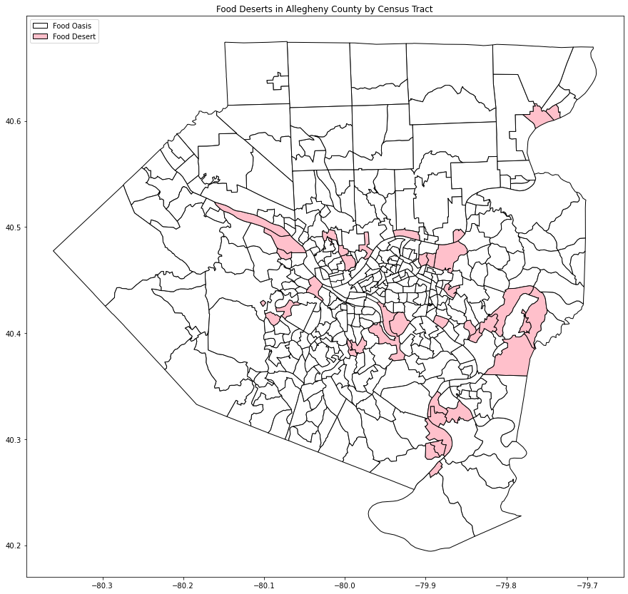

```python
# visualize the food deserts on their own
fig, ax = plt.subplots(1, 1, figsize=(15, 15))

# need to make my own colormap
cmap = ListedColormap(['white', "pink"])

ac_geo.plot(column='food_desert', edgecolor='black', cmap=cmap, ax=ax)

# creating a custom legend because it is easier to show color labels this way with my data
from matplotlib.patches import Patch
leg_colors = [Patch(facecolor='white', edgecolor='black',label='Food Oasis'),
             Patch(facecolor='pink', edgecolor='black',label='Food Desert')]
ax.legend(handles=leg_colors, loc='upper left')

ax.set_title('Food Deserts in Allegheny County by Census Tract')

plt.show()
```

## Now I can overlay the food options data with the food desert data

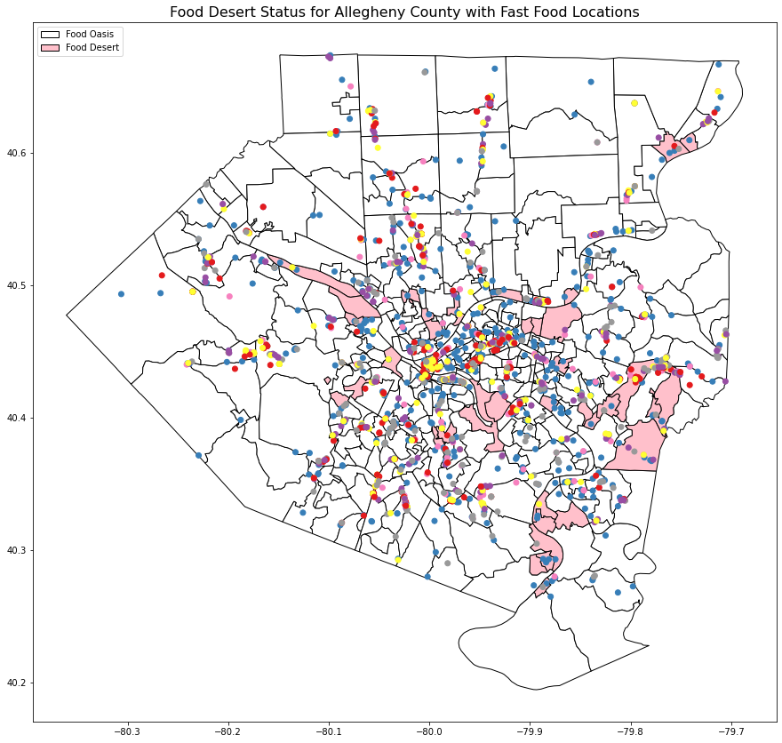

```python
# instantiate figure
fig, ax = plt.subplots(1, 1, figsize=(15, 15))

ac_geo.plot(column='food_desert', edgecolor='black', cmap=cmap, ax=ax)
foodopts.plot(column='Category', cmap='Set1', ax=ax, legend=True)

# creating a custom legend because it is easier to show color labels this way when data is binary
leg_colors = [Patch(facecolor='white', edgecolor='black',label='Food Oasis'),
             Patch(facecolor='pink', edgecolor='black',label='Food Desert')]
ax.legend(handles=leg_colors, loc='upper left')

ax.set_title('Food Desert Status for Allegheny County with Fast Food Locations', fontsize=16)

plt.show()
```

## We can clearly see the lack of food options in some of these food deserts

- While visualization can help us understand the data, it will not tell us everything.
- The number of food options in each census tract will need to be counted to be able to be used in the classification model.

```python
# need to separate convenience stores from the grocery stores data frame because they dont carry fresh food
convenient = grocery[grocery['Category'] == 'Convenience Store']

# bad food is now all fast food and convenience stores
BADfood = gpd.GeoDataFrame(fastfood.append(convenient), geometry='geometry', crs="EPSG:4326")

# good food is now only supermarkets
GOODfood = gpd.GeoDataFrame(grocery[grocery['Category'] == 'Supermarket'],geometry='geometry',crs="EPSG:4326")
```

```python
# need to do a geopandas sjoin to combine each of the food counts with the allegheny county geoDataFrame
BADcounts = gpd.sjoin(ac_geo, BADfood, how='inner')

BADcounts = pd.DataFrame(BADcounts.groupby(['CensusTract'])['Category'].count().reset_index())

BADcounts.columns = ['CensusTract','badcount']
```

```python
# and again with the healthy food options
GOODcounts = gpd.sjoin(ac_geo, GOODfood, how='inner')

GOODcounts = pd.DataFrame(GOODcounts.groupby(['CensusTract'])['Category'].count().reset_index())

GOODcounts.columns = ['CensusTract','goodcount']
```

```python
# combine bad food counts with the rest of the data
allcounts = ac_geo.merge(BADcounts, on='CensusTract',how='left').fillna(0)

# combine good food counts with the rest of the data
allcounts = allcounts.merge(GOODcounts, on='CensusTract',how='left').fillna(0)
```

## Walk scores

Next, I will add walk scores to the rest of the data that has been cleaned so far

```python
# import data, rename the columns, and ignore the first row
walkscores = pd.read_csv('walkscorect.xls-walk-score-by-ct.csv', names=['CensusTract','walkscore'], skiprows=1)

walkscores.head()
```

|  | CensusTract | walkscore |
| --- | --- | --- |
| 0 | 10300 | 82 |
| 1 | 20100 | 100 |
| 2 | 20300 | 83 |
| 3 | 30500 | 77 |
| 4 | 40200 | 71 |

```python
## These census tracts can be changed to match the full census tract that is used in the main DataFrame
walkscores = walkscores.astype(str)

# first need to add a zero on to front of the census tracts with only 5 characters
walkscores['CensusTract'] = walkscores['CensusTract'].str.zfill(6)
# then add the state and county code to the front of the tract
walkscores['CensusTract'] = '42003' + walkscores['CensusTract']

# back to int
walkscores = walkscores.astype(int)

walkscores.head()
```

|  | CensusTract | walkscore |
| --- | --- | --- |
| 0 | 42003010300 | 82 |
| 1 | 42003020100 | 100 |
| 2 | 42003020300 | 83 |
| 3 | 42003030500 | 77 |
| 4 | 42003040200 | 71 |

```python
## now I can merge the scores with the rest of the data
allcounts = allcounts.merge(walkscores, on='CensusTract')
```

## The final dataset will now be added which contains information on educational attainment for Allegheny county

```python
# import data which was exported from the US Census website
eduattn = pd.read_csv('educationattain.csv')

# could skip the first row here to make the descriptions the actual column names but it will be much longer
eduattn.head()
```

|  | GEO_ID | B23006_001E | B23006_001M | B23006_002E | B23006_002M | B23006_003E | B23006_003M | B23006_004E | B23006_004M | B23006_005E | B23006_005M | B23006_006E | B23006_006M | B23006_007E | B23006_007M | B23006_008E | B23006_008M | B23006_009E | B23006_009M | B23006_010E | B23006_010M | B23006_011E | B23006_011M | B23006_012E | B23006_012M | B23006_013E | B23006_013M | B23006_014E | B23006_014M | … |
| --- | --- | --- | --- | --- | --- | --- | --- | --- | --- | --- | --- | --- | --- | --- | --- | --- | --- | --- | --- | --- | --- | --- | --- | --- | --- | --- | --- | --- | --- | --- |
| 0 | id | Estimate!!Total | Margin of Error!!Total | Estimate!!Total!!Less than high school graduate | Margin of Error!!Total!!Less than high school ... | Estimate!!Total!!Less than high school graduat... | Margin of Error!!Total!!Less than high school ... | Estimate!!Total!!Less than high school graduat... | Margin of Error!!Total!!Less than high school ... | Estimate!!Total!!Less than high school graduat... | Margin of Error!!Total!!Less than high school ... | Estimate!!Total!!Less than high school graduat... | Margin of Error!!Total!!Less than high school ... | Estimate!!Total!!Less than high school graduat... | Margin of Error!!Total!!Less than high school ... | Estimate!!Total!!Less than high school graduat... | Margin of Error!!Total!!Less than high school ... | Estimate!!Total!!High school graduate | Margin of Error!!Total!!High school graduate | Estimate!!Total!!High school graduate!!In labo... | Margin of Error!!Total!!High school graduate!!... | Estimate!!Total!!High school graduate!!In labo... | Margin of Error!!Total!!High school graduate!!... | Estimate!!Total!!High school graduate!!In labo... | Margin of Error!!Total!!High school graduate!!... | Estimate!!Total!!High school graduate!!In labo... | Margin of Error!!Total!!High school graduate!!... | Estimate!!Total!!High school graduate!!In labo... | Margin of Error!!Total!!High school graduate!!... | … |
| 1 | 1400000US42003010300 | 745 | 810 | 42 | 37 | 0 | 109 | 0 | 109 | 0 | 109 | 0 | 109 | 0 | 109 | 42 | 37 | 452 | 542 | 172 | 178 | 0 | 109 | 172 | 178 | 149 | 179 | 23 | 37 | … |
| 2 | 1400000US42003020100 | 3311 | 365 | 428 | 119 | 10 | 17 | 0 | 109 | 10 | 17 | 10 | 17 | 0 | 109 | 418 | 116 | 1262 | 214 | 207 | 95 | 0 | 109 | 207 | 95 | 206 | 95 | 1 | 109 | … |
| 3 | 1400000US42003020300 | 388 | 136 | 31 | 39 | 8 | 13 | 0 | 109 | 8 | 13 | 8 | 13 | 0 | 109 | 23 | 36 | 67 | 70 | 26 | 40 | 0 | 109 | 26 | 40 | 26 | 40 | 0 | 109 | … |
| 4 | 1400000US42003030500 | 844 | 112 | 105 | 63 | 28 | 30 | 0 | 109 | 28 | 30 | 16 | 24 | 12 | 18 | 77 | 61 | 376 | 138 | 229 | 100 | 0 | 109 | 229 | 100 | 214 | 90 | 15 | 23 | … |

## I looked through the columns and determined which contained total counts of educational attainment and which contained the population estimate

```
1: B23006_001E: Population
2: B23006_002E: total less than high school graduate
3: B23006_009E: total high school graduate
4: B23006_016E: total "some college" or associates degree
5: B23006_023E: total bachelor's degree or higher
```

```python
# take the above mentioned columns and the extended census tract from the imported DataFrame
ed = eduattn[['GEO_ID', 'B23006_001E', 'B23006_002E', 'B23006_009E', 'B23006_016E', 'B23006_023E']]

# rename the columns
newcolumns = {'GEO_ID':'CensusTract', 'B23006_001E':'population', 'B23006_002E': 'dropout',
              'B23006_009E':'high_school', 'B23006_016E':'associate', 'B23006_023E':'bachelor'}
ed = ed.rename(columns=newcolumns)

# need to drop the first row with the column labels
ed = ed.iloc[1:]

## walkscores had a shortened census tract and educational attainment has the extended which i will now shorten
ed['CensusTract'] = ed['CensusTract'].str[9:]

# and change all data types to integer so that mathematical operations can be performed
ed = ed.astype(int)

# perform mathematical operations
## divide counts for each census tract by the stated population
ed['dropout'] = ed['dropout'] / ed['population']
ed['high_school'] = ed['high_school'] / ed['population']
ed['associate'] = ed['associate'] / ed['population']
ed['bachelor'] = ed['bachelor'] / ed['population']

ed.head()
```

|  | CensusTract | population | dropout | high_school | associate | bachelor |
| --- | --- | --- | --- | --- | --- | --- |
| 1 | 42003010300 | 745 | 0.056376 | 0.606711 | 0.179866 | 0.157047 |
| 2 | 42003020100 | 3311 | 0.129266 | 0.381154 | 0.194201 | 0.295379 |
| 3 | 42003020300 | 388 | 0.079897 | 0.172680 | 0.059278 | 0.688144 |
| 4 | 42003030500 | 844 | 0.124408 | 0.445498 | 0.074645 | 0.355450 |
| 5 | 42003040200 | 750 | 0.030667 | 0.328000 | 0.280000 | 0.361333 |

```python
## finally, I will combine the educational attainment data with the rest of the data
allcounts = allcounts.merge(ed, on='CensusTract')

### resulting dataFrame is very large, I can shorten it to be the necessary variables needed for classification
alldata = allcounts[['food_desert','PovertyRate', 'MedianFamilyIncome','TractSeniors','TractWhite','TractBlack',
                     'TractAsian','TractNHOPI','TractAIAN','TractOMultir','TractHispanic','TractSNAP',
                     'obesity_rate', 'diabhyper_rate','badcount', 'goodcount', 'dropout','high_school',
                     'associate','bachelor','walkscore']]

alldata.head()
```

|  | food_desert | PovertyRate | MedianFamilyIncome | TractSeniors | TractWhite | TractBlack | TractAsian | TractNHOPI | TractAIAN | TractOMultir | TractHispanic | TractSNAP | obesity_rate | diabhyper_rate | badcount | goodcount | dropout | high_school | associate | bachelor | walkscore |
| --- | --- | --- | --- | --- | --- | --- | --- | --- | --- | --- | --- | --- | --- | --- | --- | --- | --- | --- | --- | --- | --- |
| 0 | 0 | 46.124524 | 17161.0 | 0.016364 | 0.658333 | 0.311667 | 0.011061 | 0.000303 | 0.001970 | 0.016667 | 0.024394 | 0.015152 | 0.25 | 0.043 | 7.0 | 0.0 | 0.056376 | 0.606711 | 0.179866 | 0.157047 | 82 |
| 1 | 0 | 17.465070 | 137463.0 | 0.119592 | 0.745660 | 0.159824 | 0.047120 | 0.000551 | 0.002204 | 0.044640 | 0.032791 | 0.068338 | 0.67 | 0.027 | 79.0 | 0.0 | 0.129266 | 0.381154 | 0.194201 | 0.295379 | 100 |
| 2 | 0 | 6.372549 | 124722.0 | 0.071429 | 0.756494 | 0.155844 | 0.063312 | 0.000000 | 0.001623 | 0.022727 | 0.016234 | 0.000000 | 0.37 | 0.031 | 8.0 | 4.0 | 0.079897 | 0.172680 | 0.059278 | 0.688144 | 83 |
| 3 | 0 | 39.484215 | 26976.0 | 0.207890 | 0.136082 | 0.824911 | 0.010638 | 0.000000 | 0.003103 | 0.025266 | 0.014184 | 0.207890 | 0.49 | 0.141 | 4.0 | 1.0 | 0.124408 | 0.445498 | 0.074645 | 0.355450 | 77 |
| 4 | 0 | 47.884013 | 34813.0 | 0.081029 | 0.527266 | 0.385177 | 0.064900 | 0.000000 | 0.002688 | 0.019969 | 0.023425 | 0.086022 | 0.37 | 0.095 | 1.0 | 0.0 | 0.030667 | 0.328000 | 0.280000 | 0.361333 | 71 |

# This dataframe is now ready to be used for machine learning.

## Before running the models, we can visualize the relationships between each of the varibles and food desert status

```python
import seaborn as sns
```

### Violin Plot of Obesity VS Food Desert status

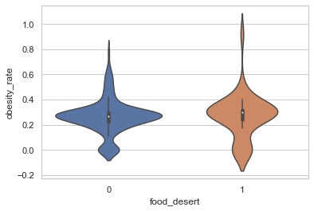

```python
sns.set_theme(style="whitegrid")

sns.violinplot(y=alldata['obesity_rate'], x=alldata['food_desert'])

plt.show()
### this shows that while the obesity rate does get much higher when located in a food desert...
### the amount of census tracts with an average obesity rate, is higher in a food oasis
```

### Multiple bivariate KDE plots of Obesity and Supermarket counts separated by Food Desert status

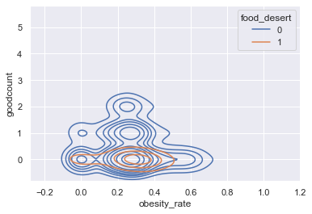

```python
sns.set_theme(style='darkgrid')

sns.kdeplot(data=alldata, x='obesity_rate', y='goodcount', hue='food_desert', thresh=0.1)

plt.show()
## we can clearly see here that food deserts have only 1 or 0 supermarket locations
# and obesity rate again doesn't show much correlation
```

## Bar Plots

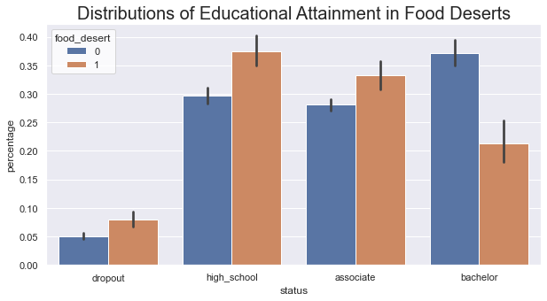

```python
# separate the education data from the rest
educate = alldata[['food_desert','dropout','high_school','associate','bachelor']]
# melt the education dataframe with the food desert values so that i can plot the education data categorically
melted = educate.melt('food_desert', var_name='status', value_name='percentage')

fig, ax = plt.subplots(1, 1, figsize=(10, 5))
ax.set_title('Distributions of Educational Attainment in Food Deserts', size=20)

sns.set_theme(style='whitegrid')

sns.barplot(y="percentage", x="status", hue="food_desert", data=melted)

plt.show()
## we can see from this bar plot that bachelor's degree or higher eduation attainment is the only category where
## food desert status is less likely than food oasis
```

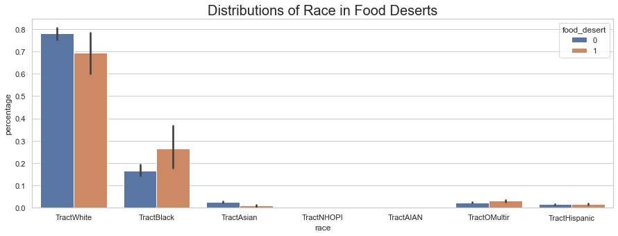

```python
# we can do the same with race
racial = alldata[['food_desert', 'TractWhite','TractBlack','TractAsian',
                  'TractNHOPI','TractAIAN','TractOMultir','TractHispanic']]
# melt the data....
melted = racial.melt('food_desert', var_name='race', value_name='percentage')

fig, ax = plt.subplots(1, 1, figsize=(15, 5))
ax.set_title('Distributions of Race in Food Deserts', size=20)

sns.set_theme(style='whitegrid')

sns.barplot(y="percentage", x="race", hue="food_desert", data=melted)

plt.show()
#### we can see hear the majority of people in Allegheny County are white
## we can also clearly see that white people are less likely to live in a food desert
## and black people are more likely to like in a food desert
```

## Swarm Plot

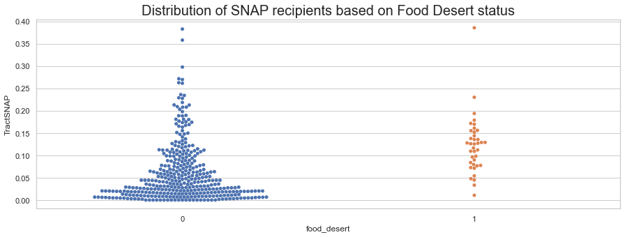

```python
sns.set_theme(style='whitegrid')

fig, ax = plt.subplots(1, 1, figsize=(15, 5))
ax.set_title('Distribution of SNAP recipients based on Food Desert status', size=20)

sns.swarmplot(data=alldata, y='TractSNAP', x='food_desert')

plt.show()
### here we can see that the amount of census tracts with a very low percentage of SNAP benefits being received,
### are much higher when in a food oasis
```

## Correlation Heat Map

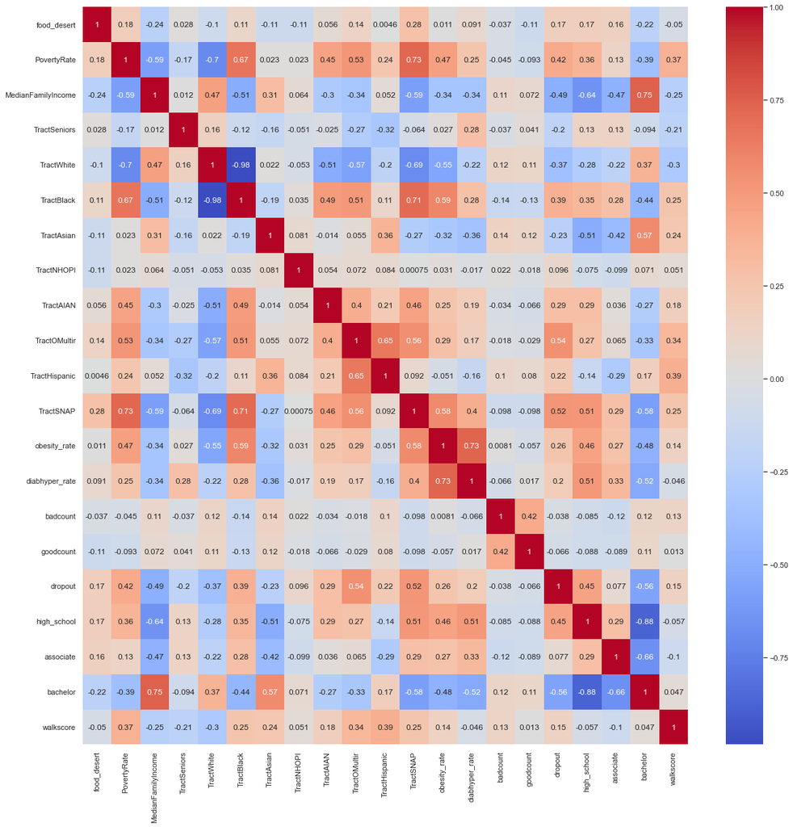

```python
fig, ax = plt.subplots(1, 1, figsize=(20,20))

sns.heatmap(alldata.corr(),cmap='coolwarm',annot=True)

plt.show()
```

### This HUGE correlation heat map shows us that there is not just one or two factors that highly correlate with food desert status

There are 5 factors which all seem to have a **low** correlation of around 0.20

1. Tract SNAP recipients (the *most* correlated with 0.28)
2. Poverty Rate
3. High school dropout maximum educational attainment
4. High school graduate
5. Associates degree or "some college"

# Classification

- I will run the following 6 different classification models on this data and determine which model is best when predicting food desert status
  - K-nearest Neighbor
  - Naive Bayes
  - Gaussian Process Classifier
  - Decision Tree
  - Random Forest
  - Ada Boost
- After that, I will use that model and determine the feature importances for each feature in my dataframe

```python
# import necessary packages
from sklearn.model_selection import train_test_split
from sklearn.preprocessing import StandardScaler

from sklearn.neighbors import KNeighborsClassifier
from sklearn.naive_bayes import GaussianNB
from sklearn.gaussian_process import GaussianProcessClassifier
from sklearn.tree import DecisionTreeClassifier
from sklearn.ensemble import RandomForestClassifier, AdaBoostClassifier
```

```python
features = ['PovertyRate', 'MedianFamilyIncome','TractSeniors','TractWhite','TractBlack',
            'TractAsian','TractNHOPI','TractAIAN','TractOMultir','TractHispanic','TractSNAP', 'obesity_rate',
            'diabhyper_rate','badcount', 'goodcount', 'dropout','high_school',
            'associate','bachelor','walkscore']

# found 5 NA values in X data that needed dropped
alldata = alldata.dropna()

X = alldata[features]
y = alldata['food_desert']
```

### Before classification... I will determine if dimensionality reduction is needed for this data by PCA analysis

```python
from sklearn.decomposition import PCA

# scale and transform the features
scaler = StandardScaler()
X_features = scaler.fit_transform(X)

X_features.shape
```

```
(396, 20)
```

```python
pca = PCA()

pca.fit(X_features)
```

```
PCA()
```

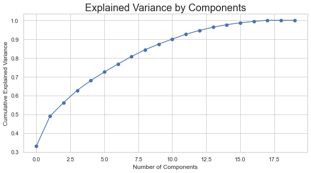

```python
plt.figure(figsize=(10,5))
plt.plot(np.cumsum(pca.explained_variance_ratio_), marker='o')
plt.title('Explained Variance by Components', size=20)
plt.xlabel('Number of Components')
plt.ylabel('Cumulative Explained Variance')

plt.show()
```

## This shows that 15 out of the 20 variables account for about 98% of the variance

Due to this, I chose not to used dimensionally reduced data in the classification models. PCA would also get rid of the feature names which would prevent me from calculating the feature importance